# Introduction To Bayesian Data Analysis

Hannah Hodge Waller

[figure not shown]

Course Release: June 2021 | Need help? Contact the team.

# 1 Course Outline

- Course Outline and Information - please read carefully.
- Packages and Data
- What is Bayesian Data Analysis
- Examples of Bayesian Analysis
- A refresher on Probability
- Bayes’ Theorem
- The Monty Hall Problem
- Components of Bayesian Analysis
- Approximate Bayesian Computation
- Quadratic Approximation
- Markov Chain Monte Carlo (MCMC)
- Summarising Posterior Distributions
- Bayesian Linear Regression Models
- Summary
- References

## 1.1 Learning Outcomes

By the end of this course you should have a basic knowledge of Bayesian Data Analysis and how it can be done in Python or R.

## 1.2 Prerequisite Knowledge:

This course assumes that you have basic statistical and mathematical knowledge. No prior knowledge of Bayesian analysis is required.

This course also assumes basic R and Python knowledge as demonstrated in the Introduction to R and Introduction to Python courses. This includes reading in data and data manipulation using tidyverse (R) and pandas (python).

Additional packages will need to be installed for these courses; it is assumed you will know how to install additional packages, including setting up your computer to do so if required (e.g ONS’ Artifactory system, [instructions can be found at this link](http://np2rvlapxx507/BPI/coding-getting-started-guide/-/wikis/home)).

## 1.3 Course Format:

This course is written in both the Python and the R programming language.

Where code is provided it will be presented in tabs; one for Python and one for R. Please choose the tab with the language you wish to use.

An example is below.

## Code Examples

### **Python**

```python
print("This tab contains Python code")
```

```
## This tab contains Python code
```

### **R**

```r
print("This tab contains R code")
```

```
## [1] "This tab contains R code"
```

## 1.4 Duration

This course should take approximately 6 hours to complete.

# 2 Packages and Data

## 2.1 Packages

### **Python Packages**

We have found this course does not work with Python version 3.6 due to errors with pycm3; we recommend updating to more modern version of Python. This course is written using Python 3.8.3. - which is part of the current Anaconda installation within ONS.

```python
# Print Python Version
print(sys.version)
```

```
## 3.8.3 (default, Jul  2 2020, 17:30:36) [MSC v.1916 64 bit (AMD64)]
```

Package requirements:

Note:

Pymc3 is a tricky package to install. It is recommended that you work with a new virtual environment and install PyMC3 first; and then any other dependencies (in this case just statsmodels)

Advice on installation can be found on the pyMC3 Github for Microsoft Windows and Mac OS - note that m2w64-toolchain is not available on ONS machines; this affects the speed of some samplers; but is not an essential part for this course.

**ONS** Advice on virtual environments using Conda, Virtual Env and attaching these to a Jupyter Notebook can be found here [internal ONS guidance](http://np2rvlapxx507/BPI/coding-getting-started-guide/-/wikis/home)

**Other Departments** This online Guidance on using [virtualenv](https://realpython.com/python-virtual-environments-a-primer/) and [conda enviroments](https://conda.io/projects/conda/en/latest/user-guide/tasks/manage-environments.html) may be useful. This information about using [virtual enviroments in Jupyter Notebooks](https://janakiev.com/blog/jupyter-virtual-envs/) may also be useful.

- pymc3
- pandas
- numpy
- matplotlib.pyplot
- scipy.stats

```python
import pymc3 as pm
```

```
## WARNING (theano.tensor.blas): Using NumPy C-API based implementation for BLAS functions.
```

```python
import pandas as pd
import numpy as np
import matplotlib.pyplot as plt
from scipy.stats import binom, norm, uniform, triang, gaussian_kde
import statsmodels.api as sm

#%matplotlib inline # Uncomment this line if you're using a Jupyter Notebook
```

This course has been written using the following package versions:

```python
print("pymc3 Version:", pm.__version__ )
```

```
## pymc3 Version: 3.11.2
```

```python
print("Pandas Version:", pd.__version__ )
```

```
## Pandas Version: 1.2.4
```

```python
print("Numpy Version:", np.__version__ )
```

```
## Numpy Version: 1.20.3
```

```python
print("Matplotlib Version:", matplotlib.__version__ )
```

```
## Matplotlib Version: 3.2.2
```

```python
print("Scipy Version:", scipy.__version__ )
```

```
## Scipy Version: 1.6.3
```

```python
print("Statsmodels version:", sm.__version__)
```

```
## Statsmodels version: 0.12.2
```

### **R Packages**

This course was written in R Version

```r
# Find R Version
version
```

```
##                _
## platform       x86_64-w64-mingw32
## arch           x86_64
## os             mingw32
## system         x86_64, mingw32
## status
## major          4
## minor          0.2
## year           2020
## month          06
## day            22
## svn rev        78730
## language       R
## version.string R version 4.0.2 (2020-06-22)
## nickname       Taking Off Again
```

And Uses the packages -

```r
library(dplyr)
library(readr)
library(ggplot2)
library(MCMCpack)
library(bayesplot)
library(HDInterval)
library(tidybayes)
library(patchwork)
```

This course has been written using the following package versions:

```r
cat("dplyr Version:", dplyr_v)
```

```
## dplyr Version: 1.0.6
```

```r
cat("readr Version:", readr_v)
```

```
## readr Version: 1.4.0
```

```r
cat("ggplot2 Version:", ggplot2_v)
```

```
## ggplot2 Version: 3.3.3
```

```r
cat("MCMCpack Version:", mcmcpack_v)
```

```
## MCMCpack Version: 1.5.0
```

```r
cat("Bayesplot Version:", bayesplot_v)
```

```
## Bayesplot Version: 1.8.0
```

```r
cat("HDInterval Version:", hdinterval_v)
```

```
## HDInterval Version: 0.2.2
```

```r
cat("Tidybayes VersionL", tidybayes_v)
```

```
## Tidybayes VersionL 2.3.1
```

```r
cat("Patchwork Version", patchwork_v)
```

```
## Patchwork Version 1.1.1
```

## 2.2 Data

Both Python and R courses use the same data.

criminals - a dataframe containing 3000 rows and 2 columns with information about finger length and height (both in cm) of male criminals recorded in the early 1900s.

### **Python Data**

```python
titanic = pd.read_csv("../data/titanic.csv")
criminals = pd.read_csv("../data/criminals_1902.csv")
```

### **R Data**

```r
titanic <- readr::read_csv("../data/titanic.csv") # note the lower case variable; do not overwrite the built in Titanic dataframe.
criminals <- readr::read_csv("../data/criminals_1902.csv")
```

# 3 What is Bayesian Data Analysis?

Named after Thomas Bayes (1702-1761) who wrote an article about what we would now term “Bayesian Inference” that was published posthumously. Bayesian analysis is a statistical paradigm that answers research questions about unknown parameters using probability statements.

> “Bayesian inference is no more than counting the number of ways things can happen, according to our assumptions. Things that can happen more ways are more plausible.”

> - Richard McElreath, *Statistical Rethinking*

Bayesian data analysis is a method for figuring out unknowns using three things:

- Data
- A generative model (a model that can simulate data)
- Priors: existing information or current knowledge.

When parameters are known data can be simulated; using Bayesian inference we can estimate parameters from data.

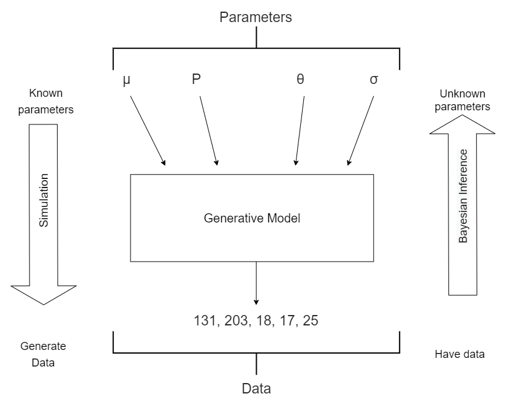

## 3.1 Bayesian Vs Frequentist

In the Bayesian approach the parameters that we are trying to estimate are treated as random variables; compared to fixed values in the frequentist approach. Random variables in Bayesian are governed by things like mean and variance and their distributions such as Binomial, Gaussian, Poisson etc.

Priors are prior belief about these parameters; the Bayesian approach can be thought of as treating probabilities as degrees of belief; rather than frequencies generated by an unknown process.

## 3.2 Advantages and Disadvantages of Bayesian Approaches

There’s a lot of material out there about the advantages and disadvantages of Bayesian techniques that expands beyond the scope of this course.

The advantages of a Bayesian approach are that it is possible to incorporate prior observations and prior knowledge. It’s also useful with complex models and for missing data and several layers of variability. Bayesian approaches can be used to make management decisions based on data; including unlikely scenarios.

Bayesian can be a computationally expensive technique, and there is considerations around “priors” (assumptions around our data), and that we may sometimes need to use weakly informative priors; and that experimentation with priors can sometimes influence results.

More reading can be found online; a few examples of sources are [from the UN’s FAO](http://www.fao.org/3/Y1958E/y1958e07.htm) and this documentation for [SAS](https://documentation.sas.com/doc/en/pgmsascdc/9.4_3.3/statug/statug_introbayes_sect015.htm)

# 4 Examples of Bayesian Analysis

There are several famous examples of using Bayesian statistics.

## Alan Turing

Alan Turing used Bayesian methods while cracking the enigma code; the Enigma was a cryptographic (enciphering) machine used by the German military in WWII. The German navy changed part of the Enigma keys every other day, giving a small window to decipher the code. One of the important cryptanalytic attacks against the navy was called “Banburismus”; a sequential Bayesian procedure that anticipated sequential analysis. More detailed information can be found in this paper by [Leeds University](http://www.mathcomp.leeds.ac.uk/turing2012/Images/Turing_Statistics.pdf). To credit solving the Enigma code completely to Turing’s team is a little erroneous; and credit must also be given to Polish mathematicians and the [Bomba cryptography](https://en.wikipedia.org/wiki/Bombe) too - however that’s probably more detail than is needed for this course.

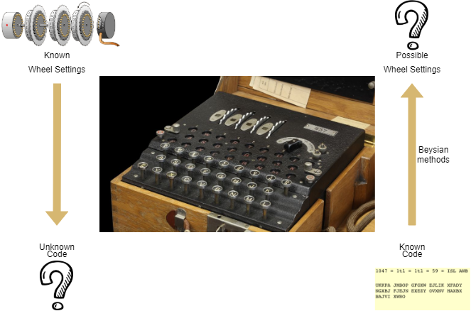

Image Sources:  
[Enigma Machine](https://polandin.com/38967258/original-enigma-to-be-purchased-by-museum-of-polish-history) | [Enigma Machine Wheels](https://www.cryptomuseum.com/crypto/enigma/m3m4.htm) | [Enigma Machine Code](https://www.matematiksider.dk/enigma_eng.html)

## Nate Silver

Nate Silver is an American statistician who used Bayesian methods to forecast the wins of Barrack Obama in the United States presidential elections in 2008 and 2012 elections. Although his team (working for Silvers’ website FiveThirtyEight) did *not* predict Donald Trump’s win in 2016; they did project a much higher probability of Trump winning than other pollsters. Silver does not like the term “predict” instead referring to his work as "rendering forecasts based on ‘conditional probability’.

## In medicine

Bayesian approaches are commonly used with medical data. While there is substantial data collected at a population level, the amount of data on any individual may be limited. Appropriately quantifying uncertainty is crucial for making decisions, especially where the optimal decision is often driven by the probability of relatively rare events; such are rare diseases or extreme reactions to a drug. Many universities are creating specialist departments, such as Lancaster University’s [Bayes4Health](https://www.lancaster.ac.uk/bayes-for-health/) to better understand how Bayesian techniques can be applied to the “big data” using Data Science techniques.

## ONS COVID-19 Infection Survey

ONS uses a Bayesian model in the Coronavirus(COVID-19) Infection Survey to provide 95% credible intervals. Selected households take nasal and throat swabs; these are then analysed in laboratories. Participants are swabbed at least once, then encouraged to have repeat tests every week for the first 5 weeks then monthly for a period of 12 months. Some individuals may also have blood tests. More detail about the collection methodology can be found on the [COVID-19 Infection Survey: methods and further information web page](https://www.ons.gov.uk/peoplepopulationandcommunity/healthandsocialcare/conditionsanddiseases/methodologies/covid19infectionsurveypilotmethodsandfurtherinformation#test-sensitivity-and-specificity)

Bayesian analysis is also used to understand the impact of false-positive and false-negative tests. The prevalence for various different observed positivity rates can be calculates using different assumptions about the test sensitivity and specificity. The full methodology can be found at the following link ["Test Sensitivity and Specificity - COVID-19 Infection Survey: methods and further information](https://www.ons.gov.uk/peoplepopulationandcommunity/healthandsocialcare/conditionsanddiseases/methodologies/covid19infectionsurveypilotmethodsandfurtherinformation#test-sensitivity-and-specificity)

These are just a few examples of the use of Bayesian statistics - there’s many more including A/B testing, robotics and machine learning.